# Regression Models for ‘Motor Trend’

Bojan Zunar

29 July 2018

# 1 Summary

We explore the relationship between a set of variables and miles per gallon (MPG) (outcome), especially to answer the two questions:

- “Is an automatic or manual transmission better for MPG?”
- “Can we quantify the MPG difference between automatic and manual transmissions?”

We conclude that cars with manual transmission have significantly higher MPG than cars with automatic transmission (7.25 mpg higher, on average). However, modelling MPG only through transmission accounts for only 34% of the variance in MPG. Better linear model, which explains 82% of the variance in MPG, accounts for the number of cylinders and weight of the car, both of which lower MPG as their values rise.

# 2 Exploratory data analysis

We load `mtcars` dataset, look at the structure of the data using `head` function and confirm that the dataset does not contain missing values.

```r
library(dplyr); library(car); library(ggplot2); library(ggfortify); library(tidyr); library(scales); library(ggsci); library(purrr)

data(mtcars); head(mtcars, 3)
```

```
##                mpg cyl disp  hp drat    wt  qsec vs am gear carb
## Mazda RX4     21.0   6  160 110 3.90 2.620 16.46  0  1    4    4
## Mazda RX4 Wag 21.0   6  160 110 3.90 2.875 17.02  0  1    4    4
## Datsun 710    22.8   4  108  93 3.85 2.320 18.61  1  1    4    1
```

```r
mtcars %>% is.na %>% table
```

```
## .
## FALSE
##   352
```

We explore the dataset by plotting how car characteristics impact fuel consumption (milesPerGallon).

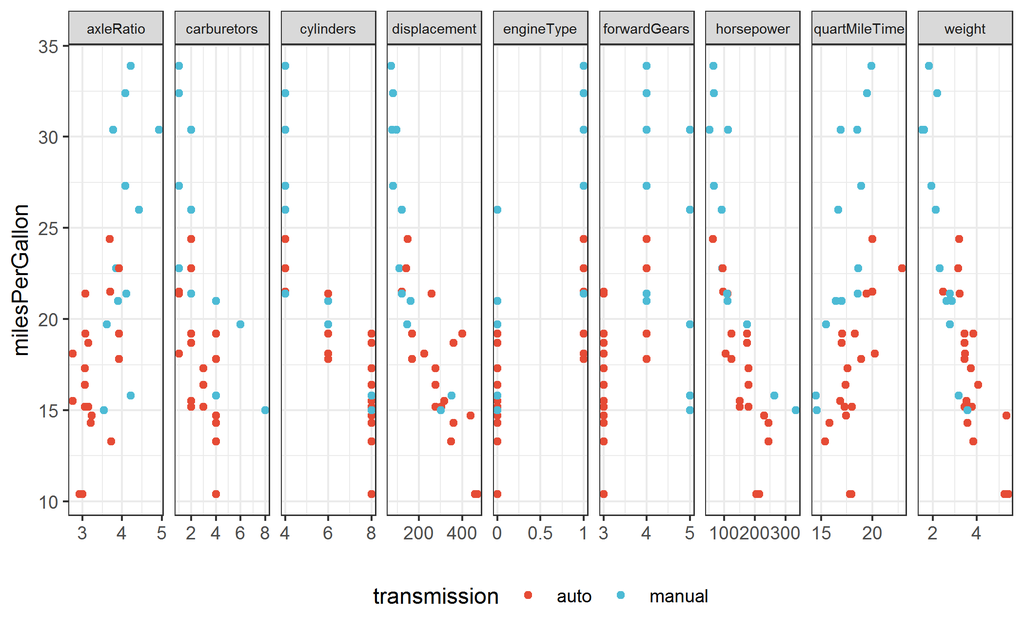

```r
data(mtcars)
mtcars %>%
    purrr::set_names(c("milesPerGallon", "cylinders", "displacement", "horsepower",
                        "axleRatio", "weight", "quartMileTime", "engineType",
                        "transmission", "forwardGears", "carburetors")) %>%
    dplyr::mutate(transmission = factor(transmission)) %>%
    gather(-milesPerGallon, -transmission, key = "var", value = "value") %>%
    ggplot(aes(x = value, y = milesPerGallon, color = transmission)) +
    geom_point() +
    facet_grid(~ var, scales = "free") +
    theme_bw() +
    theme(legend.position = "bottom", axis.title.x = element_blank(),
          strip.text.x = element_text(size = 7)) +
    scale_color_manual(labels = c("auto", "manual"), values = pal_npg("nrc")(2)) +
    scale_x_continuous(breaks = scales::pretty_breaks(n = 3),
                       labels = function(x) round(as.numeric(x), digits=2))
```

Figure 1 suggests we could model fuel consumption (MPG) with several independent variables (i.e. regressors), e.g. number of cylinders, horsepower, and weight. It also shows that cars with manual transmission have smaller fuel consumption (i.e. larger MPG) than those with automatic transmission, although the two groups overlap. Thus, exploratory data analysis suggests that manual transmission benefits MPG.

We rename variables into a human-readable format and, if appropriate, convert them into factors.

```r
colnames(mtcars) <- c("milesPerGallon", "cylinders", "displacement", "horsepower",
                      "axleRatio", "weight", "quarterMileTime", "engineType",
                      "transmission", "forwardGears", "carburetors")
mtcars$transmission[mtcars$transmission == 0] <- "auto"
mtcars$transmission[mtcars$transmission == 1] <- "manual"
mtcars$engineType[mtcars$engineType == 0] <- "V"
mtcars$engineType[mtcars$engineType == 1] <- "S"
mtcars$forwardGears <- factor(mtcars$forwardGears)
mtcars$cylinders <- factor(mtcars$cylinders)
```

# 3 Selection of regression model

First, we fit a linear model using `mpg` variable as an outcome and `transmission` variable as the only regressor. As regressor is a factor, it is modelled as a binary variable. Therefore, the coefficient of the intercept represents the mean value of MPG for cars with automatic transmission (17.147). The model shows that the coefficient for the manual transmission is positive (7.245) and that it differs significantly from the intercept (p = 0.000285). Therefore, cars with manual transmission have significantly higher MPG than cars with automatic transmission, with an average of 24.392 (17.147 + 7.245). While this model agrees with our previous conclusion, it explains only 33.85% of the variance in MPG (adjusted R<sup>2</sup>).

```r
fit0 <- lm(milesPerGallon ~ transmission, data = mtcars)
summary(fit0)$coefficients
```

```
##                     Estimate Std. Error   t value     Pr(>|t|)
## (Intercept)        17.147368   1.124603 15.247492 1.133983e-15
## transmissionmanual  7.244939   1.764422  4.106127 2.850207e-04
```

```r
cat("Adjusted R-squared:",  summary(fit0)$adj.r.squared)
```

```
## Adjusted R-squared: 0.3384589
```

To obtain a model that explains more variance in the dataset, we fitted a linear model using `mpg` as the outcome and all other variables as regressors. In the linear model, none of the regression coefficients was significant, although the model explained 81.16% of the variance in MPG. Large variance inflation factors indicated that highly correlated regressors were included in the model. Thus, the inclusion of correlated variables needlessly inflated standard errors of the regressors.

```r
fit_all <- lm(milesPerGallon ~ ., data = mtcars)
cat("Range of coefficients' p-values:", range(summary(fit_all)$coefficients[,4]))
```

```
## Range of coefficients' p-values: 0.07886857 0.738245
```

```r
cat("Adjusted R-squared:",  summary(fit_all)$adj.r.squared)
```

```
## Adjusted R-squared: 0.811563
```

```r
cat("Range of generalized VIF:",  range(vif(fit_all)[,1]))
```

```
## Range of generalized VIF: 5.099622 44.44661
```

We performed ANOVA (analysis of variance) to identify superfluous variables. The analysis pointed to `cylinders`, `displacement`, and `weight` as the only significant terms.

```r
anova(fit_all) %>% .[5] %>% t
```

```
##           cylinders displacement horsepower axleRatio     weight
## Pr(>F) 5.953408e-09  0.009139155   0.116598 0.2027343 0.01013378
##        quarterMileTime engineType transmission forwardGears carburetors
## Pr(>F)       0.6423417  0.8358414    0.1362714    0.6977407    0.456767
##        Residuals
## Pr(>F)        NA
```

We created a series of nested models which used `mpg` as the output. Each model differed from the previous one by an additional term ANOVA flagged as significant. Comparison of these models showed that model with regressors `cylinders` and `weight` (**fit2**) is significantly better than model with either only `cylinders` (**fit1**) or `cylinders`, `weight` and `displacement` (**fit3**) as regressors.

```r
fit1 <- lm(milesPerGallon ~ cylinders, data = mtcars)
fit2 <- update(fit1, milesPerGallon ~ cylinders + weight)
fit3 <- update(fit1, milesPerGallon ~ cylinders + weight + displacement)
anova(fit1, fit2, fit3)[1:6]
```

```
##   Res.Df    RSS Df Sum of Sq       F    Pr(>F)
## 1     29 301.26
## 2     28 183.06  1    118.20 17.4448 0.0002769 ***
## 3     27 182.95  1      0.11  0.0162 0.8997211
## ---
## Signif. codes:  0 '***' 0.001 '**' 0.01 '*' 0.05 '.' 0.1 ' ' 1
```

Such linear model explained 82% of variance in the data and it showed that MPG decreases with number of cylinders (-4.25 mpg if the car has 6 cylinders and -6.07 mpg if the car has 8 cylinders, compared to car with 4 cylinders) and that it decreases with the weight of the car (-3.21 mpg for every 1000 lbs).

```r
summary(fit2)$coefficients
```

```
##              Estimate Std. Error   t value     Pr(>|t|)
## (Intercept) 33.990794  1.8877934 18.005569 6.257246e-17
## cylinders6  -4.255582  1.3860728 -3.070244 4.717834e-03
## cylinders8  -6.070860  1.6522878 -3.674214 9.991893e-04
## weight      -3.205613  0.7538957 -4.252065 2.130435e-04
```

```r
cat("Adjusted R-squared:",  summary(fit2)$adj.r.squared)
```

```
## Adjusted R-squared: 0.8200146
```

Adding `transmission` as regressor did not improve the model.

```r
fit4 <- update(fit2, milesPerGallon ~ cylinders + weight + transmission)
anova(fit2, fit4)[1:6]
```

```
##   Res.Df    RSS Df Sum of Sq      F Pr(>F)
## 1     28 183.06
## 2     27 182.97  1  0.090314 0.0133 0.9089
```

Finally, we plot residuals for model **fit2** (Additional Figure 2). The absence of pattern and of large residuals indicate that the model adequately fits the data.

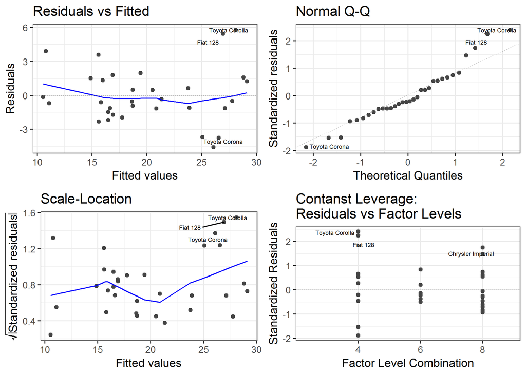

```r
autoplot(fit2, label.size = 2, label.repel = TRUE) +
    theme_bw()
```

**Figure 2: Residual plots.** A set of diagnostic plots (showing leverage and influence measures) used to determine if calculated residuals indicate poor model fit with the data.